# STAT GU4206/5206 Midterm

Christine Chong cc4190

June 8, 2017

The STAT GU4206/5206 midterm is open notes, open book(s), and online resources are allowed. Students are **not** allowed to communicate with any other people during the midterm with the exception of the GU4206/5206 instructor. When you are finished with the midterm, please upload both the .pdf and .Rmd files on Canvas.

For the entire midterm we consider the **Auto** dataset taken from the *Introduction to Statistical Learning* package. Before starting the midterm, make sure the package **ISLR** is installed on your laptop.

```r
#install.packages("ISLR")
library(ISLR)
```

# Problem 1: Basic Operations

## 1.i)

Display the first 3 rows of the **Auto** dataset:

```r
head(Auto,3)
```

```
##   mpg cylinders displacement horsepower weight acceleration year origin
## 1  18         8          307        130   3504         12.0   70      1
## 2  15         8          350        165   3693         11.5   70      1
## 3  18         8          318        150   3436         11.0   70      1
##                        name
## 1 chevrolet chevelle malibu
## 2         buick skylark 320
## 3        plymouth satellite
```

## 1.ii)

How many rows are in this dataset?

```r
nrow(Auto)
```

```
## [1] 392
```

# Problem 2: Regression and the Bootstrap

## 2.i)

Consider extracting only the rows corresponding to 6 cylinder cars. Also consider running a linear regression on a car’s acceleration versus its weight. The working filtering and linear regression code is displayed below.

```r
Auto.6.cyl <- Auto[Auto$cylinders==6,]
beta.hats <- coef(lm(acceleration~weight,data=Auto.6.cyl))
beta.hats
```

```
## (Intercept)      weight
## 4.368123570 0.003711944
```

Identify the estimated slope and intercept of the above linear model.

## 2.ii)

Now suppose as researchers, we want to infer upon the true slope relating a six cylinder car’s acceleration versus its weight. Also suppose that we do not want to make strong assumptions on the errors of the linear regression model; hence we will perform a bootstrap procedure. Below is *almost complete* working code that runs a bootstrap procedure for the slope. Fill in the one missing line of **R** code and make sure to uncomment each line below. Run the bootstrap procedure after filling in the missing line.

```r
 set.seed(0)
 B <- 1000
 n <- nrow(Auto.6.cyl)
 slopes.boot <- rep(NA,B)
 for (b in 1:B) {
   sample.boot <- sample(1:n, n, replace = TRUE )
   regression.boot <- lm(acceleration~weight,data=Auto.6.cyl[sample.boot,])
   slopes.boot[b] <- coef(regression.boot)[2]

 }
 slope.hat <- beta.hats[2]
 LL <- 2*slope.hat-quantile(slopes.boot,.975)
 UL <- 2*slope.hat-quantile(slopes.boot,.025)
 c(LL,UL)
```

```
##      weight      weight
## 0.002748981 0.004727104
```

## 2.iii)

At 5% significance, is a six cylinder car’s acceleration statistically related to its weight? Support your answer using the computed bootstrap interval **c(LL,UL)**.

**Solution:**

Due to the value at 5% significance being not 0, it is safe to say that a six cylinder’s car accleration is stastiscally related. If the number was closer to 1, it would have more of a significant relation.

## 2.iv)

Create a histogram of the bootstrapped slope estimates. Make sure to label the histogram appropriately and use 30 breaks for the bins.

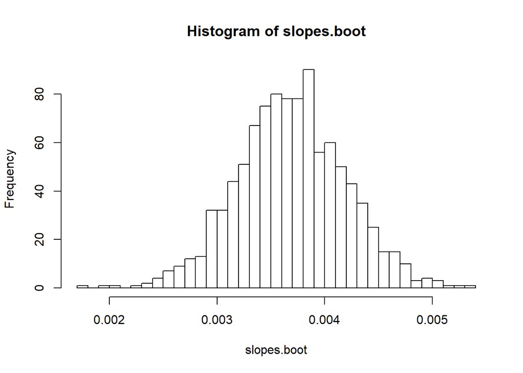

```r
hist(slopes.boot, breaks = 30)
```

# Problem 3: Subseting

The original **Auto** datafrme consists of cars with 3,4,5,6 and 8 cylinders. Create a new dataframe named **Auto.new** that consists of only the cars with 4,6 and 8 cylinders. Check that the number of rows in this new dataframe is equal to 385.

```r
newdata <- rbind(Auto[Auto$cylinders == "4",], Auto[Auto$cylinders =="6",], Auto[Auto$cylinders =="8",])
Auto.new <- data.frame(newdata)
dim(Auto.new)
```

```
## [1] 385   9
```

# Problem 4: Character Srings and Regular Expressions

## 4.i)

Look at the first few cases of the variable **name**.

```r
head(Auto$name)
```

```
## [1] chevrolet chevelle malibu buick skylark 320
## [3] plymouth satellite        amc rebel sst
## [5] ford torino               ford galaxie 500
## 304 Levels: amc ambassador brougham ... vw rabbit custom
```

Notice that the first word in each string is the car’s company, i.e., chevrolet, buick, toyota, etc… Append a new variable on the **Auto.new** dataframe named **company** that displays the company of each car. For example, if the **name** of the car is “chevrolet chevelle malibu”, then the car’s company should be “chevrolet”. Show the first three observations in this new dataset.

Note: You might have to convert the factor variable back into a character variable.

```r
max = nrow(Auto.new)
Auto.new$name <- as.character(Auto.new$name)
for(i in 1:max){
  new <- strsplit(Auto.new$name[i], split = " ")
  unlistnew <- unlist(new)
  titlecompany <- unlistnew[1]
  titlecompany
  Auto.new$company[i] <- titlecompany
}
head(Auto.new, 3)
```

```
##    mpg cylinders displacement horsepower weight acceleration year origin
## 15  24         4          113         95   2372         15.0   70      3
## 19  27         4           97         88   2130         14.5   70      3
## 20  26         4           97         46   1835         20.5   70      2
##                            name    company
## 15        toyota corona mark ii     toyota
## 19                 datsun pl510     datsun
## 20 volkswagen 1131 deluxe sedan volkswagen
```

## 4.ii)

```r
loc1<-grep("toyouta", Auto.new$name)
Auto.new$name[loc1] <- "toyota corona mark ii(sw)"
loc2<-grep("vokswagen", Auto.new$name)
Auto.new$name[loc2] <- "volkswagen rabbit"
Auto.new$name[loc1]
```

```
## [1] "toyota corona mark ii(sw)"
```

```r
Auto.new$name[loc2]
```

```
## [1] "volkswagen rabbit"
```

# Problem 5: The Apply Family

## 5.i)

```r
horsemax <- tapply(Auto.new$horsepower, Auto.new$company, max)
horsemax
```

```
##           amc          audi           bmw         buick      cadillac
##           190            95           113           225           180
##         capri     chevroelt     chevrolet         chevy      chrysler
##            92           105           220           200           215
##        datsun         dodge          fiat          ford            hi
##           132           210            90           215           193
##         honda         maxda         mazda mercedes-benz       mercury
##            97            65            75           120           208
##        nissan    oldsmobile          opel       peugeot      plymouth
##            88           180            90           133           215
##       pontiac       renault          saab        subaru        toyota
##           230            83           115            93           122
##       toyouta       triumph     vokswagen    volkswagen         volvo
##            97            88            62            78           125
##            vw
##            76
```

## 5.ii)

Using the appropriate apply function, compute the average value of quantitative variables **mpg**, **displacement**, **horsepower**, **weight** and **acceleration**. To save some time I provided the vector of character strings in the below code chunk.

```r
variables <- c("mpg","displacement","horsepower","weight","acceleration")
apply(Auto.new[variables],2,mean)
```

```
##          mpg displacement   horsepower       weight acceleration
##     23.44545    196.06364    104.69610   2982.62078     15.54104
```

# Problem 6: R Base Graphics

Construct a base **R** plot that shows a car’s acceleration ($Y$) versus a its weight ($X$) split by the number of cylinders in the car (4,6, and 8). Note that you should be using the **Auto.new** dataset. For full credit, create the scatter plot and split the data up by different colors to represent the number of cylinders. Also create a legend and label the plot appropriately.

For extra credit, plot regression lines for each subgroup, i.e., plot 3 least squares lines: one line for 4 cylinders, one line for 6 cylinders and one line for 8 cylinders.

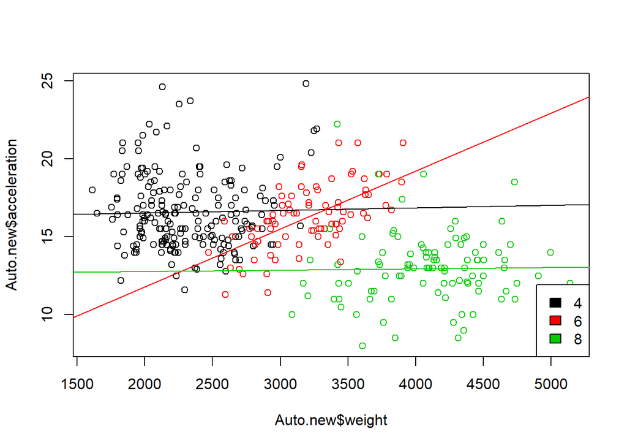

```r
plot(Auto.new$weight, Auto.new$acceleration, col= factor(Auto.new$cylinders))
legend("bottomright", legend = levels(factor(Auto.new$cylinders)), fill = unique(factor(Auto.new$cylinders)))
cylinders <- levels(factor(Auto.new$cylinders))
col_counter <- 1
for (i in cylinders) {
  this_cylinder    <- Auto.new$cylinders == i
  this_data   <- Auto.new[this_cylinder, ]
  this_lm     <- lm((this_data$acceleration)
                    ~(this_data$weight))
  abline(this_lm, col = col_counter)
  col_counter <- col_counter + 1
}
```